# Donor Profile: UN Joint Programmes (Government of)

## Focus Portfolio

The UN Joint Programme portfolio for 2025 commands significant strategic attention with a consolidated funding pool of $8.25 million dedicated to critical regional interventions. This singular, substantial investment presents a unique leverage point to amplify donor impact by scaling proven cross-sectoral initiatives within the UNHCR framework. Given the absence of diversified funding streams, there is an urgent opportunity to broaden partnership engagement to mitigate concentration risks and ensure operational resilience. Prioritizing expansion of donor coalitions will unlock multi-stakeholder collaboration, acting as a force multiplier for emergency response and resilience-building efforts aligned with donor priorities. We recommend immediate executive action to position this funding envelope as a flagship investment avenue, emphasizing transparent impact measurement and accountability mechanisms to solidify trust and catalyze sustained resource mobilization. Donor engagement strategies should highlight the exceptional scale and focused deployment potential of this funding to inspire confidence and accelerate contribution commitments.

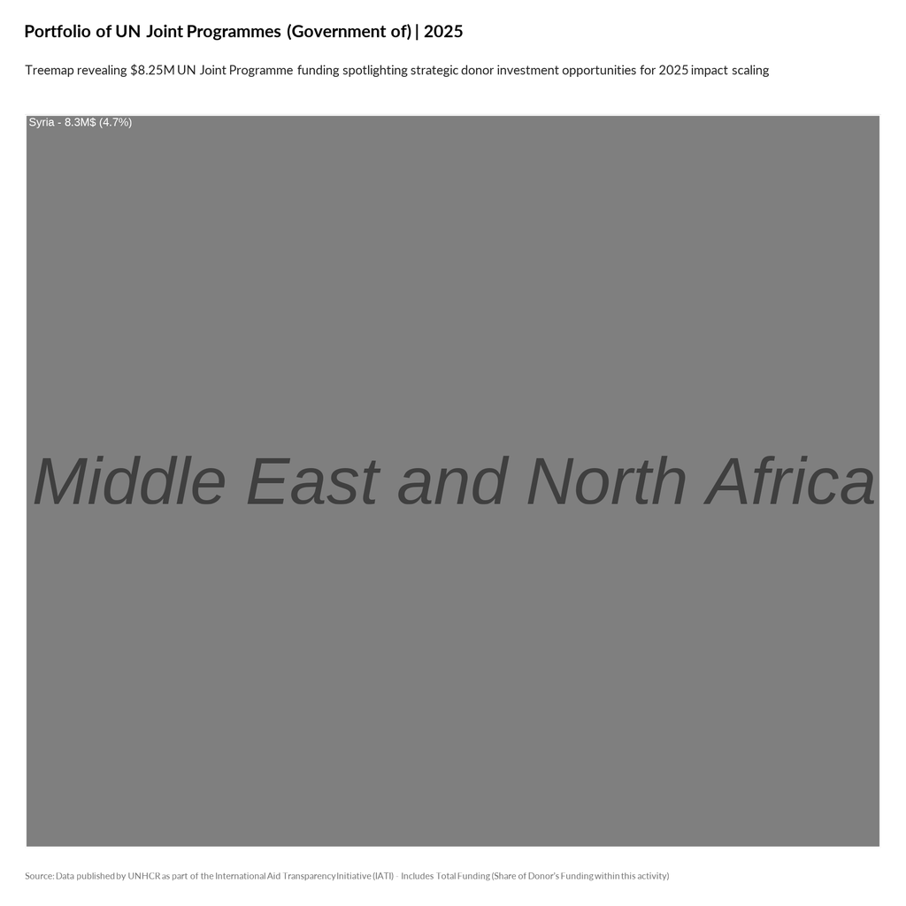

TRUE

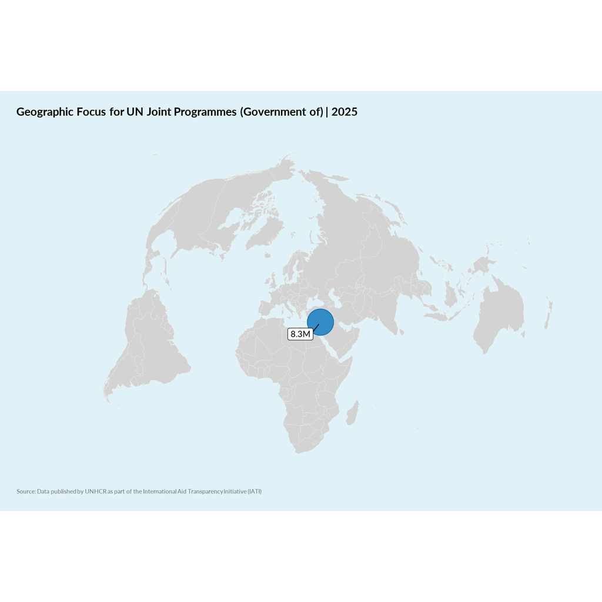

TRUE